# R Structures

## Arithmetic and algebra

```
[1] 10
```

You can also run just one line at a time by putting your cursor on a line and pressing *Cmd+Enter*. Then, you’ll just see the output for the one line.

## Functions

factorial(round(2.0015) + 1)

What happened in your Environment when you ran that code?

## Code Chunk Options

There are a lot of things you can do in a code chunk: you can produce text output, tables, or graphics.

You also have control over all these output via chunk options, which can be provided inside the curly braces (between ```{r and }).

`echo=FALSE` indicates that the code will not be shown in the final document (though any results/output would still be displayed).

```
[1] 0.8667861
```

You use `results="hide"` to hide the results/output (but here the code would still be displayed).

```r
x <- rnorm(100)
y <- 2*x + rnorm(100)
cor(x, y)
```

You use `include=FALSE` to have the chunk *evaluated*, but neither the code nor its output displayed.

For figures, you’ll want to use options like fig.width and fig.height

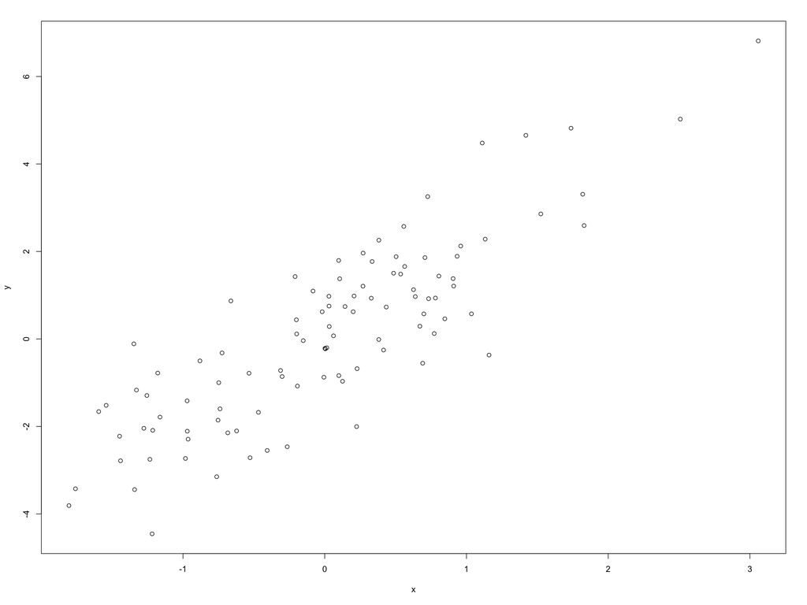

## R Markdown

Markdown provides an easy way to make standard types of formatted text, like

- *italics*
- **bold**
- `code`
- links
- Latex equations, $E = mc^{2}$
- etc.

## “knitted” HTML version

This functionality is supported by an R package called `knitr`, so we often talk about “knitted” versions of RMarkdown and R Notebook documents.

Click the *Preview* button at the top of this document or press *Cmd+Shift+K* (*Ctrl+Shift+K* on Windows) to preview the HTML file. Try clicking *Preview* now.

## More on Notebooks

We’ll be covering many more details about notebooks as we progress, but ask a TA if you have pressing questions right now.